# South African Sardine Operating Model Specification

A plausible hypothetical state of nature for investigating the tailored Climate Test.

Tom Carruthers (tom@bluematterscience.com)

2026-09-25

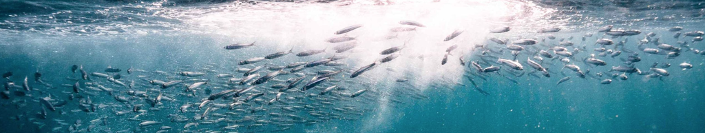

[figure not shown]

[figure not shown]

[figure not shown]

# 1 Foreword

This operating model is for conducting are exploratory, didactic analyses and is not intended to inform management decision making at this stage. All data used in the construction of these operating models are publicly available from sources that are cited.

# 2 Introduction

This operating model aims to closely mimic a [recent stock assessment for South African Sardine by de Moor (2025)](https://science.uct.ac.za/maram/2025-workshop) for the purposes of testing the robustness of management procedures to projected climate changes originating from an Atlantis Ecosystem Model ([Ortega-Cisneros et al. 2018][https://onlinelibrary.wiley.com/doi/10.1111/fog.12268]).

The assessment includes a recently revised hypothesis for sardine stock structure and includes West and South stock components with varying somatic growth ([Assessment Document BG4, de Moor 2025](https://science.uct.ac.za/sites/default/files/media/documents/science_uct_ac_za/2066/iws-2025-sardine-bg4.pdf)).

The focus of this operating model is capturing the overall stock dynamics in terms of resilience, magnitude and natural variability for the purpose of evaluating under projections, various management porcedures (MP) that set annual advice. As such the focus not capturing the detailed historical spatial and seasonal dynamics necessary to interpret historical data correctly (a primary challenge for the assessment) but rather to use the assessment estimates for evaluating MPs. For this reason the operating model is spatially aggregated and captures the stock-wide dynamics informed by the recent stock assessment.

# 3 Methods

## 3.1 OpenMSE 2.0

OpenMSE operating models were configured to match the aggregate age-structured dynamics of the [stock assessment](https://science.uct.ac.za/sites/default/files/media/documents/science_uct_ac_za/2066/iws-2025-sardine-bg4.pdf) closely matching the estimates of harvest rate, recruitment and biomass.

## 3.2 OM Initialization

```r
library(openMSE)
library(readxl)
packageVersion('MSEtool') # should be v4x
```

```
#> [1] '4.0.0'
```

```r
# AI extracted estimates of recent assessed biomass, recruitment, harvest rate, selectivity, maturity and somatic growth
est_yr =  as.data.frame(readxl::read_xlsx('Data/SA_Sardine_2025_estimates.xlsx', 'ByYear'))
est_len = as.data.frame(readxl::read_xlsx('Data/SA_Sardine_2025_estimates.xlsx', 'ByLength'))
est_age = as.data.frame(readxl::read_xlsx('Data/SA_Sardine_2025_estimates.xlsx', 'ByAge'))

# Create blank operating model and fill details
om = new('om')
om@Name = "South African Sardine"
om@Longitude = 20
om@Latitude  = -35
om@Author = 'Tom Carruthers'
om@Agency = 'Blue Matter'
om@Email = 'tom@bluematterscience.com'
om@Region = "South Africa"
om@Sponsor = "The Ocean Foundation"
om@Source = "https://climatetest.bluematterscience.com"

# Basic Config
Years = est_yr$Year           # historical year labels
ny = length(Years)            # number of historical years
om@nYear = ny                 # historical year
om@pYear = 50                 # 50 projected years
om@Interval = 1               # management updated every 1 year
om@DataLag = 1                # data available from last year (not in-season management)
om@nSim = 48                  # No. realisations of stock and fleet dynamics
om@CurrentYear = max(Years)   # label for most recent historical year
om@Years = Years(om)          # all year labels
om@Seasons = 1                # Annual OM
om@maxF = 3                   # maximum apical exploitation rate is 3.0 (harvest rate of 95%)
om@Seed = 1                   # random seed for stochastic sampling
om@Log[[1]] = paste("OM created:", Sys.Date())
```

## 3.3 Stock and Fleet Initialization

```r
stock = new('stock')
stock@Name = 'South African Sardine'
stock@CommonName = 'Sardine'
stock@Species = 'Sardinops sagax'

fleet = new('fleet')
fleet@Name = "All commercial fleets (inc directed sardine and round herring)"
```

## 3.4 Natural mortality rate

The operating model assumes the same natural mortality as the recent stock assessment (following the 2022 assessment of [de Moor (2022)](https://doi.org/10.25375/uct.22146602.v1)) that is 1.0 per year for juveniles (age 0) and 0.8 for mature fish (age 1+). The recruitment outputs we are conditioning on are end of age-0 and subject to the initial year of mortality, hence we assume zero mortality for age class zero in the OM.

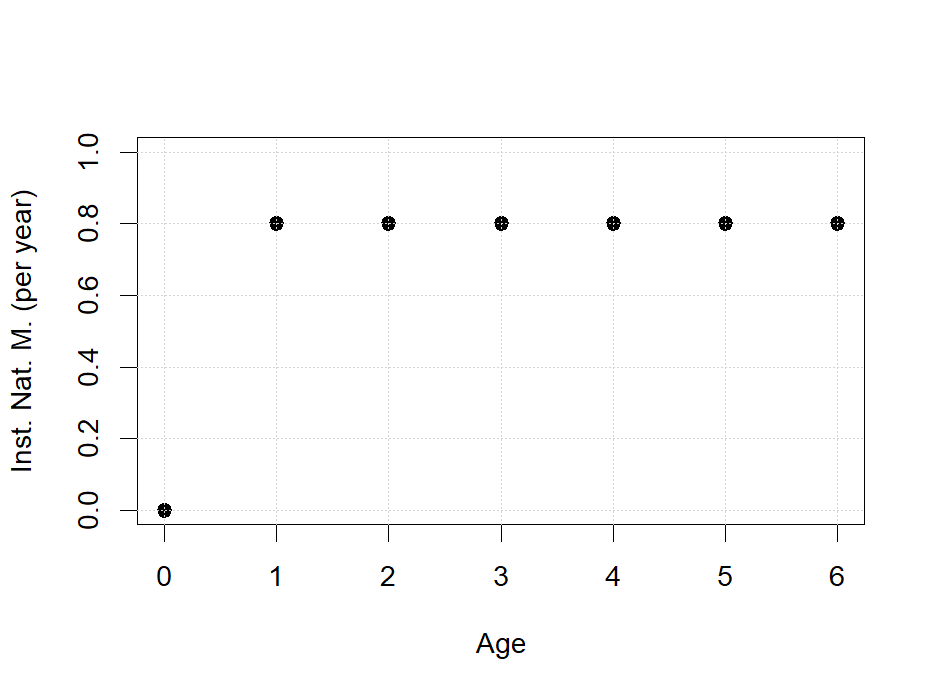

```r
stock@Ages = Ages(6, MinAge = 0)                                            # Age 6 is the last age class for calculations of age-based vectors
stock@NaturalMortality = NaturalMortality(MeanAtAge = c(0, rep(0.8, 6)))
plot(stock@Ages@Classes,stock@NaturalMortality@MeanAtAge, pch=19, lwd=2, xlab = "Age", ylim = c(0,1), ylab = "Inst. Nat. M. (per year)"); grid()
```

## 3.5 Somatic Growth

The operating model assumes an length-at-age vector that is the unweighted mean of the South and West curves used by the 2025 assessment [de Moor 2025](https://science.uct.ac.za/sites/default/files/media/documents/science_uct_ac_za/2066/iws-2025-sardine-bg4.pdf).

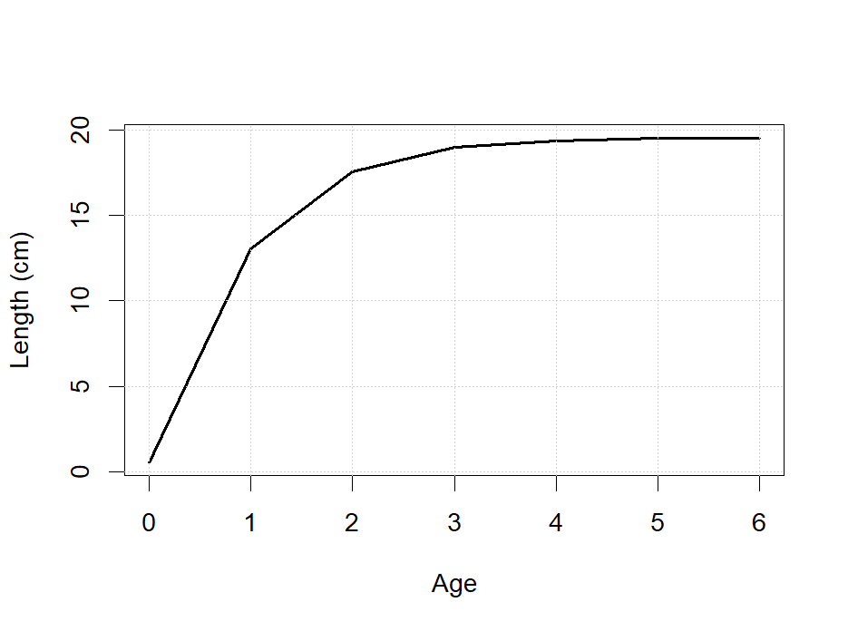

```r
Classes = 1:ceiling(max(est_age$Length)*1.3)
stock@Length = Length(MeanAtAge = c(est_age$Length,est_age$Length[6]),  # Need to add another asympotic length to make 7 age classes (first is age-0)
                      Classes = 1:ceiling(max(est_age$Length)*1.3) )    # Length classes
plot(0:6,stock@Length@MeanAtAge, lwd=2, type="l",xlab = "Age", ylab = "Length (cm)"); grid()
```

## 3.6 Weight-at-Length

The weight length-weight relationship follows that derived by OLSPS Marine. The relationship for both stock units combined is assumed to follow the relationship:

W = 0.0000071118 * L ^ 3.181 (cm - kg)

Note that if MP advice is unitless (e.g. catch in the projection relative to catch in 2024) the length-weight relationship is largely inconsequential. To obtain the same scale the length-weight relationship is exactly inversly related to unfished recruitment and numbers are not used in the model.

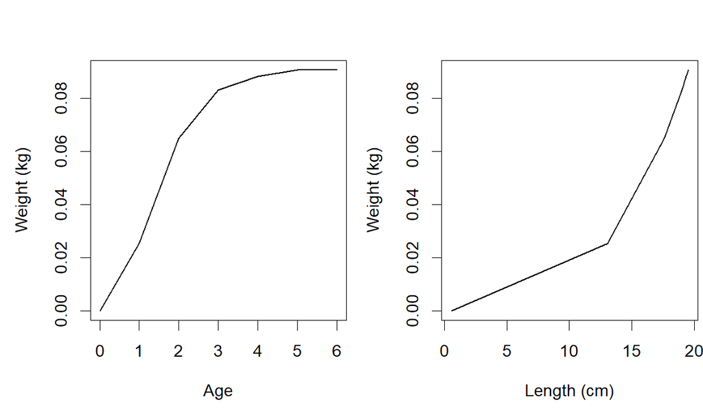

```r
LT =  stock@Length@MeanAtAge
WT =  0.0000071118 * LT ^ 3.181
stock@Weight = Weight(MeanAtAge = WT)

par(mfrow=c(1,2),mai=c(0.9,0.9,0.6,0.05))
plot(0:6, WT, xlab="Age",ylab = "Weight (kg)",type="l", lwd=1.5)
plot(LT, WT, type="l",lwd=1.5,xlab="Length (cm)",ylab = "Weight (kg)")
```

## 3.7 Maturity

The maturity ogive followed that specified by a preliminary MSE operating model of [de Moor (2025)](https://science.uct.ac.za/sites/default/files/media/documents/science_uct_ac_za/2066/iws-2025-sardine-bg5.pdf). This prescribes a logistic model with a length 50% maturity of 11.8811 cm with a rate of increase in maturity at length of 1.9311

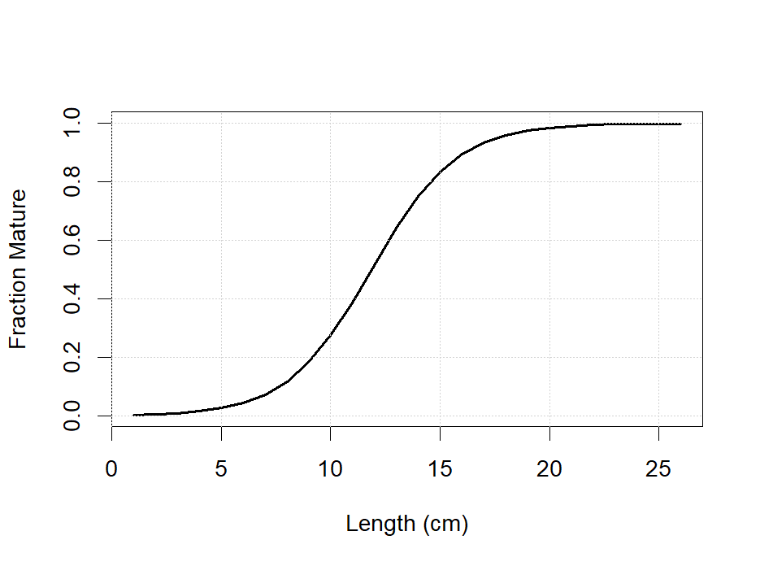

```r
stock@Maturity = Maturity(MeanAtLength = 1/(1+exp(-(Classes - 11.88)/1.93)), Classes = Classes)
plot(Classes,stock@Maturity@MeanAtLength, lwd=2, type="l",xlab = "Length (cm)", ylab = "Fraction Mature"); grid()
```

## 3.8 Recruitment

Annual recruitment estimates for the West and South stock components were summed to obtain overall stock recruitment. This was related to estimated biomass to derive two model parameters: unfished recruitment (R0, scale, carring capacity) and steepness (resilience).

This analysis should be derived from the estimates of spawning stock biomass (SSB) from the stock assessment but these are not provided in the publically available reports.

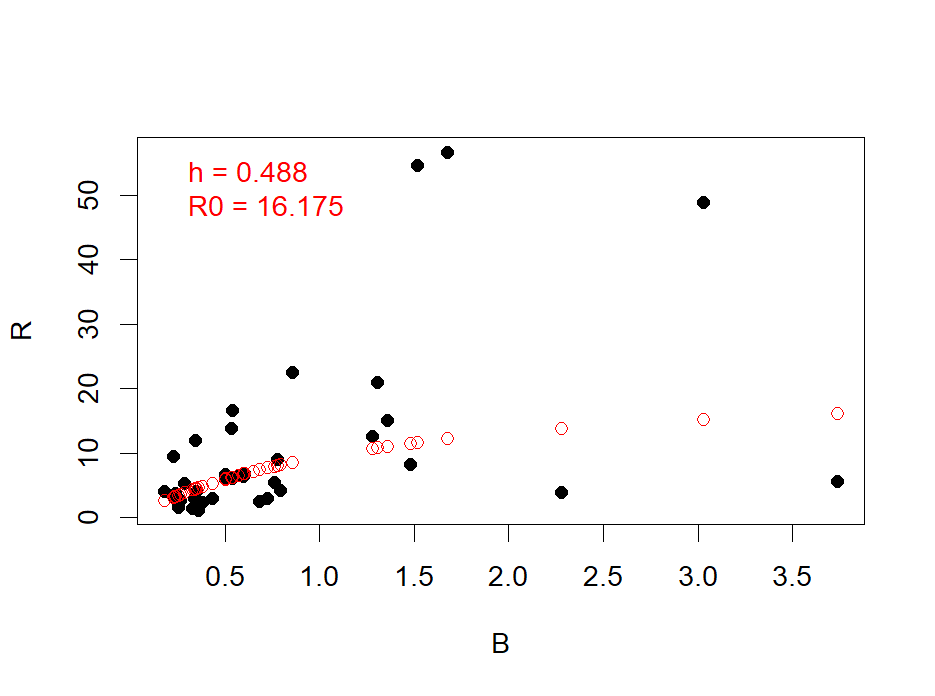

```r
B = est_yr$B_west + est_yr$B_south # Biomass Mt (could be unitless, R0 and steepness h are the targets)
R = (est_yr$R_west + est_yr$R_south) # Billions of fish (technically, rec observations are June and need inflated by age 0 M)

BH<-function(par, B, R, mode='opt', plot = F, tplot = F, curyr = 2024, pmu = 0.6, pcv = 0.1){ # optimization function for Bev-Holt SR
  h = 0.2 + 0.8 * (1 / (1 + exp(par[1]))); R0 = exp(par[2]);  BpR = max(B,na.rm=T) / R0       # logit between 0.2 and 1
  Rpred<-((0.8 * R0 * h * B) / (0.2 * BpR * R0 * (1 - h) + (h - 0.2) * B))                    # predicted recruitment
  if(plot) {plot(B,R,pch=19); points(B, Rpred,col='red');                                     # plot fitted SR curve
            legend('topleft',legend=c(paste("h =",round(h,3)),paste("R0 =",round(R0,3))),text.col="red",bty="n")}
  if(mode=='opt')return(-sum(dnorm(log(Rpred)-log(R),0,0.5,log=T), na.rm=T)-dnorm(pmu,h,pcv,log=T))  # add prior on h
  if(mode != "opt") return(log(R / Rpred))                                                    # return log rec devs
}

opt = optim(par = c(0,log(max(R,na.rm=T)/2)), BH, # optimize for h and R0 from initial values of 0.6 and half the max R
            B =  B, R = R, method = "L-BFGS-B",   # bounded optimization
            lower = c(-4,log(10)),                # broad limits
            upper = c(4,log(50)))                 # broad limits


RD = BH(opt$par, B, R, plot=T, mode = "devs") # recruitment deviations
```

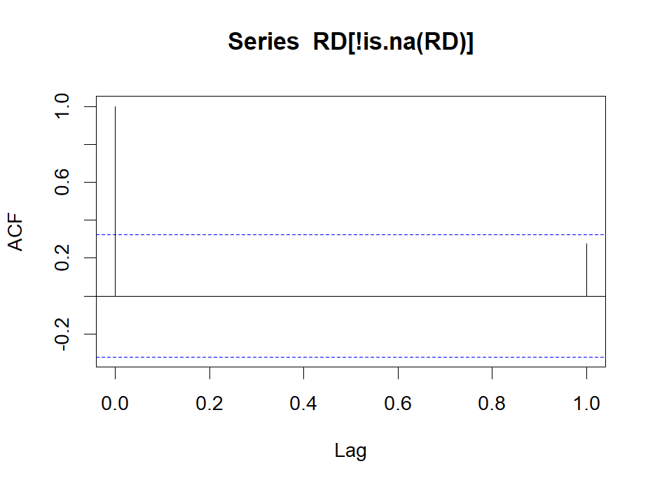

```r
R0 = exp(opt$par[2]) * 1E9                    # 'unfished' recruitment
h = 0.2 + 0.8 * (1 / (1 + exp(opt$par[1])))   # steepness of the B-H S-R function
AC = acf(RD[!is.na(RD)],1)$acf[2,1,1]         # lag-1 recruitment autocorrelation
```

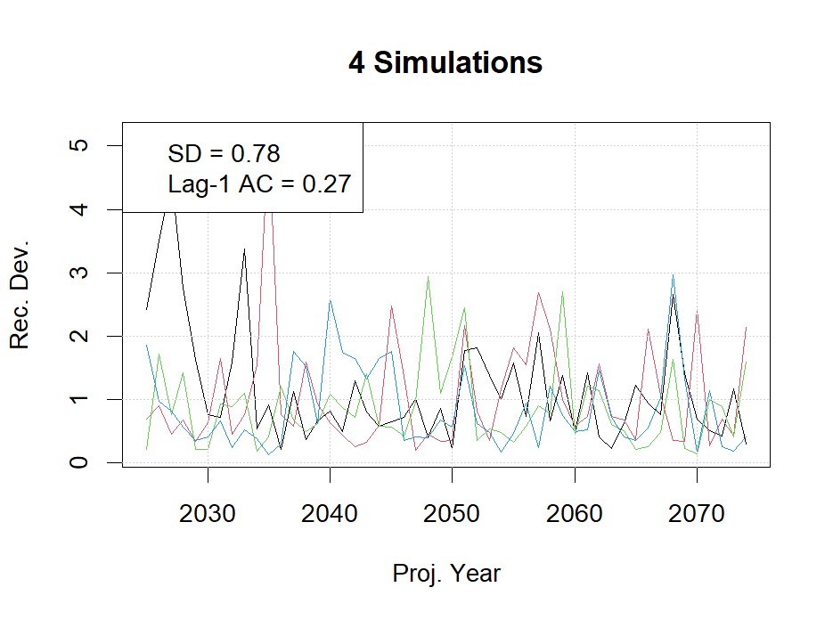

```r
SD = sd(RD, na.rm=T)                          # lognormal recruitment process error ('sigma-R')


DepGuess = (B[1]/quantile(B,0.5,na.rm=T))                                   # depletion guess
RecDevInit = matrix(DepGuess, nrow = om@nSim, ncol = stock@Ages@MaxAge)     # initial rec devs go into year 1 of RecDevHist
RecDevHist = matrix(exp(RD),nrow = om@nSim, ncol = ny, byrow = T)           # historical rec devs
RecDevProj = matrix(NA,nrow = om@nSim, ncol = om@pYear)                     # projected rec devs
nterminal = sum(is.na(RD))                                                  # No. terminal years in need of filling
fyears = rev(rev(om@Years)[1:(nterminal + om@pYear)])                       # labels for years that need filling
res = MSEtool::GenResiduals(SD, rep(AC,om@nSim), fyears, om@nSim, TruncSD = 3,
                            LastError = exp(RecDevHist[,ny-nterminal]))     # generated residuals with AC and SD
RecDevHist[,(ny-nterminal+1):ny] = res[,1:nterminal]                        # populate terminal rec devs
RecDevProj = res[, (nterminal+1):ncol(res)]                                 # populate projected rec devs

stock@SRR = SRR(Pars=list(h=h), R0 = R0, AC = AC, RecDevInit = RecDevInit,  # build Stock Rec. Rel. slot
                RecDevHist = RecDevHist, RecDevProj = RecDevProj)

matplot(Years(om, Period = "P"), t(RecDevProj[1:4,]),lty=1,type="l",
        xlab="Proj. Year",ylab ="Rec. Dev.", main="4 Simulations"); grid()
legend('topleft',legend=c(paste("SD =",round(SD,2)),paste("Lag-1 AC =", round(AC,2))))
```

The estimated stock biomass and estimated recruitment cannot be considered as independent (biomass) and dependent (recruitment) variables because biomass itself is a product of recruitment, and this is particularly the case for short-lived species such as sardine. The inter-dependency of these variables generally leads to an overestimate of stock resilience because higher than average recruitment is required at low stock sizes (and vice versa) to drive changes in the biomass levels.

This analysis should be revised and updated given SSB estimates from the assessment.

## 3.9 Selectivity

Commercial fishery selectivity follows the length-based-vector of the most recent estimated year of the stock assessment.

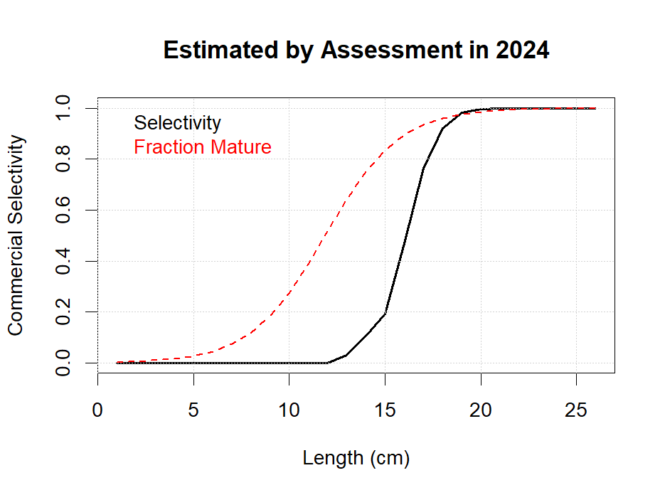

```r
nl = length(Classes)                                        # No. length classes
MeanAtLength = rep(0, nl)                                   # fill a vector with zero selectivity
ind = match(est_len$Length, Classes)                        # get correct indexing for estimated selectivity
MeanAtLength[ind] = est_len$Selectivity                     # map estimated selectivity
MeanAtLength[max(ind):nl] = 1                               # fill upper range with 100% selectivity (asymptotic)

fleet@Selectivity = Selectivity(MeanAtLength = MeanAtLength,
                                Classes = Classes)

plot(Classes,MeanAtLength, lwd=2, type="l",xlab = "Length (cm)", ylab = "Commercial Selectivity", main = "Estimated by Assessment in 2024"); grid()
lines(Classes,stock@Maturity@MeanAtLength, lwd=1.5, lty=2,col='red');
legend('topleft', legend = c("Selectivity", "Fraction Mature"),text.col = c("black","red"),bty='n')
```

## 3.10 Apical F

The stock assessment reports provide a time-series estimate of harvest rate (U) for the combined West and South components. This is converted to an guess of apical F that will be later adjusted to match historical biomass estimates.

```r
U = est_yr$U                                              # harvest rate times series (S and W combined)
Adj_vuln = 0.5                                            # apical F and selectivity curve is 50% of the biomass available (U)
F_guess = -log(1-U) / Adj_vuln                            # initial guess of F time series
Eff = matrix(F_guess, nrow=om@nSim, ncol=ny, byrow = T,
             dimnames = list(1:om@nSim,Years(om,'h')))    # Effort matrix with correct year labels
fleet@Effort = Effort(Effort = Eff)                       # Populate historical effort slot
fleet@Catchability = Catchability(Efficiency = 1)         # Populate catchability slot, F = qE, hence F = E as specified
```

## 3.11 Initial OM

```r
om@Stock = stock
om@Fleet = fleet
hist = Simulate(om)
```

## 3.12 Scale optimization

Two components of the OM specification need to be adjusted to match estimated biomass, recruitment and harvest rate: unfished recruitment (scale), apical F mismatch.

To do this we initialize the OM, estimate harvest rate, biomass and recruitment and wrap this into a bivariate optimization for unfished recruitement and apical F modifiers.

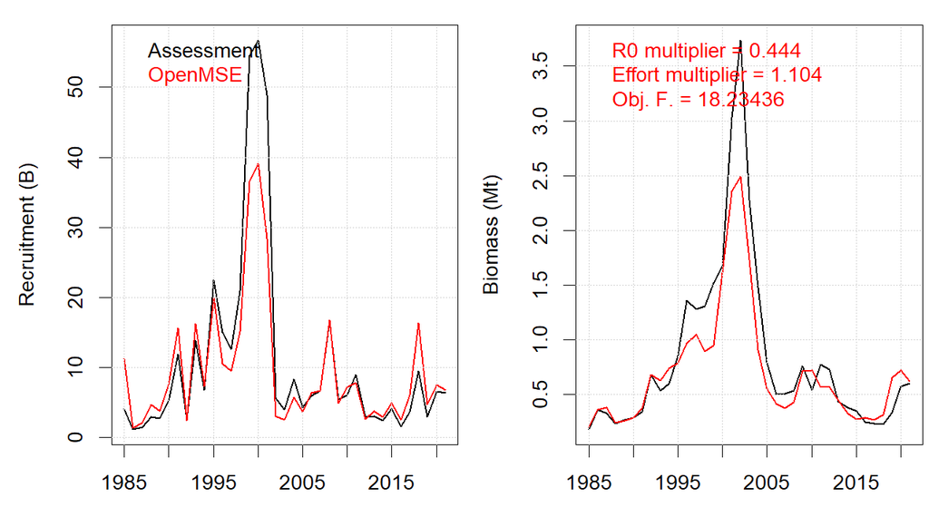

```r
ctrl = SimControl(DynamicUnfished = FALSE,
                     RefLandings = FALSE,
                     RefRemovals = FALSE,
                     ConditionObs = FALSE,
                     EstimateBeta = FALSE,
                     GenerateData = FALSE,
                     MSYRefs = FALSE,
                     RefPoints = FALSE,
                     MGT = FALSE,
                     BLow = FALSE)


Apply_pars = function(om, pars){
  R0mult = exp(pars[1])
  Emult = exp(-pars[1]) * exp(pars[2])                      # fried egg please!
  om@Stock@SRR@R0 = om@Stock@SRR@R0 * R0mult
  om@Fleet@Effort@Effort =  om@Fleet@Effort@Effort * Emult
  om
}


doplot = function(om, B, R, Best, Rest, pars, obj){
  par(mfrow =c(1,2),mai=c(0.5,0.9,0.2,0.05))
  ind = !is.na(R); yrs = Years(om, 'h')[ind]
  matplot(yrs, cbind(R[ind],Rest[ind]), ylab = "Recruitment (B)", col=c("black","red"),lty=1,lwd=1.5,type = 'l');grid()
  legend('topleft',legend=c("Assessment","OpenMSE"),text.col = c("black","red"), bty="n")
  matplot(yrs,cbind(B[ind],Best[ind]),ylab="Biomass (Mt)", col=c("black","red"),lty=1,lwd=1.5,type = 'l');grid()
  legend('topleft',legend=c(paste("R0 multiplier =",round(exp(pars[1]),3)),
                            paste("Effort multiplier =",round(exp(-pars[1]) * exp(pars[2]),3)),
                            paste("Obj. F. =", round(obj,5))), text.col = "red", bty="n")
}

plotstat = function(om2, B, R, ctrl, opt){
  hist = Simulate(om2, control=ctrl)
  Best = hist@Biomass[1,1,] * 1E-9
  Rest = hist@Number[[1]][1,1,,1] * 1E-9
  doplot(om = om2, B, R, Best, Rest, pars = opt$par, obj = opt$value)

}

Int_Scale = function(pars, om, B, R, mode = 'opt', ctrl, plot=F){
  om = Apply_pars(om, pars)
  hist = Simulate(om, control = ctrl)
  Best = hist@Biomass[1,1,] * 1E-9
  Rest = hist@Number[[1]][1,1,,1] * 1E-9
  if(mode == 'opt')  obj = sum(abs(log(Best)-log(B)),na.rm=T) + sum(abs(log(Rest)-log(R)),na.rm=T)
  if(mode == 'optB')  obj = sum(abs(log(Best)-log(B)),na.rm=T)
  if(plot) doplot(om, B, R, Best, Rest, pars, obj)
  if(grepl("opt", mode)){
    return(obj)
  }else{
    pars
  }
}

opt = optim(c(0,0), Int_Scale,
      om = om, B = B, R = R, ctrl = ctrl, plot=F,
      method = "L-BFGS-B", control = list(factr = 1E12),
      lower = c(-2, -2), upper = c(2, 2))

om2 = Apply_pars(om,opt$par)
plotstat(om2, B, R, ctrl, opt)
```

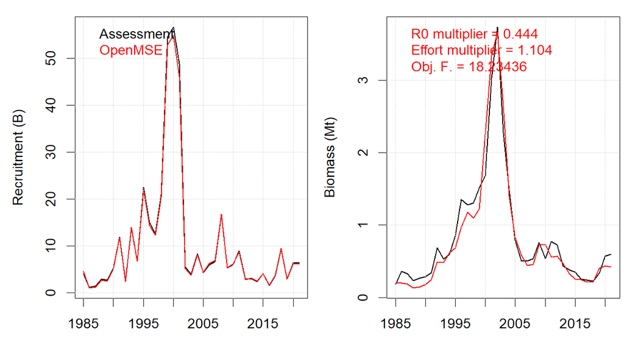

```r
for(i in 1:3){
  hist = Simulate(om2, control=ctrl)
  Best = hist@Biomass[1,1,] * 1E-9
  Rest = hist@Number[[1]][1,1,,1] * 1E-9
  #doplot(om2, B, R, Best, Rest, opt$par, obj = 0)
  ratio = matrix(R/Rest,byrow=T,nrow=om@nSim,ncol=om@nYear)
  ratio[is.na(ratio)] = 1
  R0_adj = exp(log(ratio)*0.5)
  om2@Stock@SRR@RecDevHist[] = om2@Stock@SRR@RecDevHist[] * R0_adj
}

plotstat(om2, B, R, ctrl, opt)
```

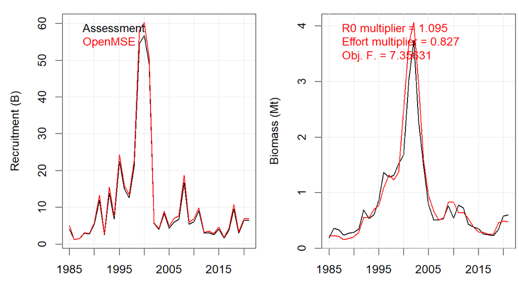

```r
opt2 = optim(c(0,0), Int_Scale,
            om = om2, B = B, R = R, ctrl = ctrl, mode = "optB", plot=F,
            method = "L-BFGS-B", control = list(factr = 1E12),
            lower = c(-1, -1), upper = c(1, 1))


om3 = Apply_pars(om2,opt2$par)

plotstat(om3, B, R, ctrl, opt2)
```

## 3.13 Add Generic Observation Model for MP Testing

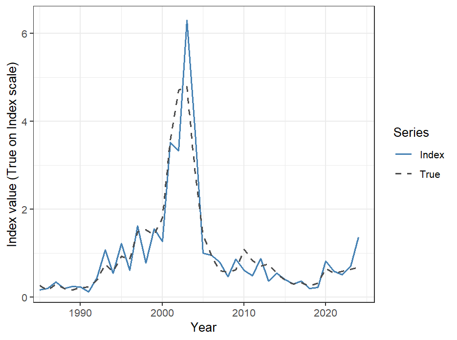

```r
ExampleObs <- Obs(CPUE = IndicesObs(CV = 0.3),                                # CPUE index
                  Survey = IndicesObs(CV = 0.2, Selectivity = 'SBiomass'),    # spawning biomass survey
                  Landings = CatchObs(CV = 0.025))                            # catches

Obs(om3) <- list(list(ExampleObs))                                            # assign observation error model

hist <- Simulate(om3)                                                         # historical reconstruction
PlotIndexFit(hist, 'CPUE')                                                    # plot historical CPUE
```

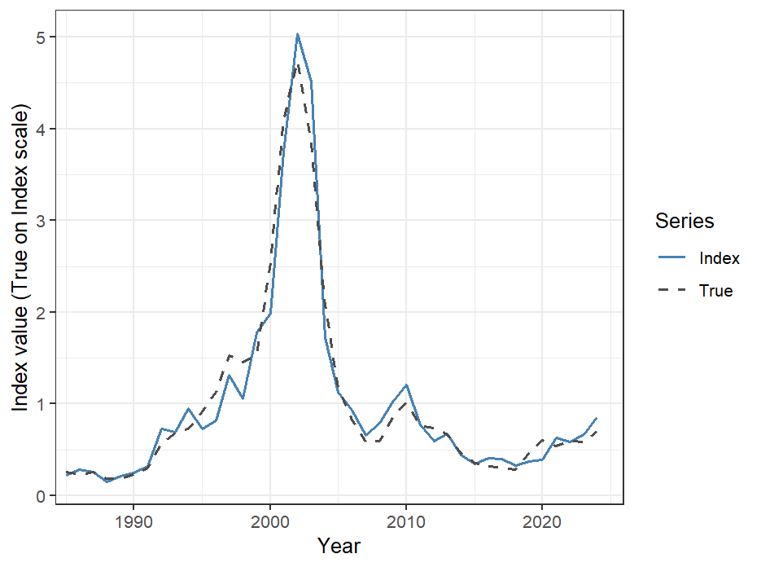

```r
PlotIndexFit(hist, 'Survey')                                                  # plot historical survey
```

```r
# Save outputs to the ClimateTest R package for lazyload
SAS = om3
save(SAS, file = "C:/GitHub/ClimateTest/data/SAS.rda")
```

# 4 Results

## 4.1 Assessment Comparison

The assessment model of de Moor (2025) includes spatial stock components, movement among areas and varying somatic growth and recruitment among areas. This complexity is required to correctly interpret input data to that model.

However, the aggregate stock-wide recruitment, exploitation rate and abundance is well approximated by the annual, spatially aggregated model applied here. This approximation is suitable for the purposes of this operating model, namely to comparatively rate climate robustness of potential management procedures.

## 4.2 Example Projections

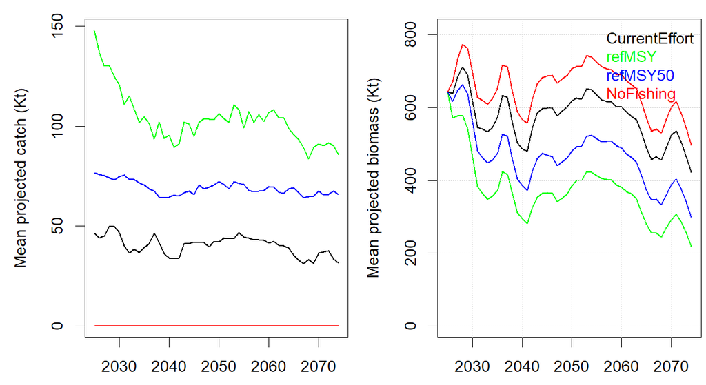

```r
Hist = Simulate(om3)
MPs = c("CurrentEffort","refMSY","refMSY50","NoFishing")
Proj = Project(Hist, MPs)
muC = apply(Proj@Landings,c(3,5),mean)
muB = apply(Proj@Biomass,c(3,4),mean)
mpcols = c("black","green","blue","red")
yrs = Years(om3, 'p')
par(mfrow =c(1,2),mai=c(0.5,0.9,0.2,0.05))
matplot(yrs, muC/1E6,type="l",lty=1, lwd=1.5, ylab="Mean projected catch (Kt)", col = mpcols)
matplot(yrs, muB/1E6,type="l",lty=1, ylim = c(0, max(muB)*1.05/1E6), lwd=1.5, ylab="Mean projected biomass (Kt)", col = mpcols); grid()
legend('topright', legend=MPs, text.col=mpcols, bty="n")
```

# 5 Version Notes

These operating models are subject to ongoing testing and development. If you find a bug or a problem please send a report to tom@bluematterscience.com so that it can be fixed!

# 6 In Development

Outstanding tasks:

| Limitation / new feature / bug | Description |
| --- | --- |
| Update SR estimations to use SSB | Currentlythe estimates of SSB from the assessment are not available |
| Possible 2 area | Extent to 2 area model with transitions |

# 7 Background information

Project information, links and results are available from the Climate Test [project webpage](https://blue-matter.github.io/ClimateTest/)

# 8 Software

## 8.1 OpenMSE

The [openMSE R package](https://openmse.com) was used to organize fishery data, define operating models, condition operating models to data, calculate reference points and specify and test existing and alternative management options.

Visit the [OpenMSE website](https://openmse.com) for more information on the framework including tutorial and case studies.

The Rapid Conditioning Model is also [described there](https://openmse.com/tutorial-rcm)

Other useful openMSE apps include [MERA](https://www.merafish.org/) for rapidly scoping operating models and [Reference Point Calculator](https://shiny.bluematterscience.com/app/rpc) for investigating reference points and control rules.

## 8.2 Climate Test

The Climate Test is an extension of OpenMSE that allows for comparative robustness evaluation of candidate management procedures. For more information please visit the [project splash page](https://climatetest.bluematterscience.com)

## 8.3 Management Strategy Evaluation

The Ocean Foundation host the [Harvest Strategies website](https://harveststrategies.org/) which is an excellent resource describing MSE, MSE concepts and how MSE can be used in fishery management including introductory videos and interviews with experts. ‘Harvest strategy’ and Management Procedure are synonymous by the way.

# 9 Climate Test Papers

[Carruthers, T.R.. 2024a. Developing the Climate Test: Robustness Trials for climate-ready management procedures. Col. Vol. Sci. Pap. ICCAT. 81(6): 1-26](https://www.iccat.int/Documents/CVSP/CV081_2024/n_6/CV08106104.pdf)

[Carruthers, T.R., 2024b. Developing the Climate Test: Performance Metrics of Climate Robustness. Col. Vol. Sci. Pap. ICCAT. 81(2): 1-7](https://www.iccat.int/Documents/CVSP/CV081_2024/n_2/CV08102148.pdf)

# 10 References

Hordyk, A., Huynh, Q., Carruthers, T. 2025. OpenMSE: An open-source R package for Management strategy evaluation, available from: https://openmse.com

# 11 Acknowledgements

ClimateTest is funded by:

The Paul M. Angell Family Foundation Oceankind The Pew Charitable Trusts

and

The Ocean Foundation in partnership with [www.HarvestStrategies.org](https://harveststrategies.org/)